# Week 10 - Lecture Notes

Author

linnea nordli

# Working with Strings

## Load libraries

```r
library(here)
library(tidyverse)
library(tidytext)
library(wordcloud)
library(janeaustenr)
```

## Intro to {stringr}

### What is a string

A string and a character are the same thing. You can tell something is a string by the presence of quotations. For example:

```r
words <- "This is a string"
words
```

```
[1] "This is a string"
```

You can also have several strings in a vector.

```r
words_vector <- c("Apples", "Bananas", "Oranges")
words_vector
```

```
[1] "Apples"  "Bananas" "Oranges"
```

### There are 4 basic families of functions in the {stringr} package:

#### Manipulation

##### = Functions that let you manipulate individual characters within the strings in character vectors.

Paste words together. This can be useful if, say, you have two columns of treatments and you want to combine them into one (e.g., high temp, low temp and high pH, low pH).

```r
paste("High temp", "Low pH")
```

```
[1] "High temp Low pH"
```

Add a dash in between the words:

```r
paste("High temp", "Low pH", sep = "-")
```

```
[1] "High temp-Low pH"
```

Remove the space in between the words:

```r
paste0("High temp", "Low pH")
```

```
[1] "High tempLow pH"
```

##### Working with vectors:

```r
shapes <- c("Square", "Circle", "Triangle") # this is a vector
paste("My favorite shape is a", shapes)
```

```
[1] "My favorite shape is a Square"   "My favorite shape is a Circle"
[3] "My favorite shape is a Triangle"
```

This is very useful when making labels for your plots.

```r
two_cities <- c("best", "worst")
paste("It was the", two_cities, "of times.")
```

```
[1] "It was the best of times."  "It was the worst of times."
```

##### Individual Characters

Let’s say you want to know how long a string is:

```r
shapes # vector of shapes
```

```
[1] "Square"   "Circle"   "Triangle"
```

```r
# useful for basepairs
str_length(shapes) # how many letters are in each word?
```

```
[1] 6 6 8
```

Let’s say you want to extract specific characters. Do you work with sequence data? This could be super useful to extract specific bases in a sequence.

```r
seq_data <- c("ATCCCGTC")

str_sub(seq_data, start = 2, end = 4) # extract the 2nd to 4th AA
```

```
[1] "TCC"
```

You can also modify strings

```r
str_sub(seq_data, start = 3, end = 3) <- "A" # add an A in the 3rd position
seq_data
```

```
[1] "ATACCGTC"
```

You can also duplicate patterns in your strings. Here we duplicate it 2 and 3 times:

```r
str_dup(seq_data, times = c(2, 3)) # times is the number of times to duplicate each string
```

```
[1] "ATACCGTCATACCGTC"         "ATACCGTCATACCGTCATACCGTC"
```

#### Whitespace

##### = Tools to add, remove, and manipulate whitespace.

##### Remove

Say you have a column and you did not copy and paste your treatments like you learned in the first week of class. You now have some words with extra white spaces and R thinks it’s an entirely new word. Here is how to deal with that:

```r
badtreatments <- c("High", " High", "High ", "Low", "Low")
badtreatments
```

```
[1] "High"  " High" "High " "Low"   "Low"
```

Remove white space:

```r
str_trim(badtreatments) # this removes both
```

```
[1] "High" "High" "High" "Low"  "Low"
```

You can also just remove from one side or the other:

```r
str_trim(badtreatments, side = "left") # this removes left
```

```
[1] "High"  "High"  "High " "Low"   "Low"
```

##### Add

The opposite of str_trim() is str_pad(), to add white space to either side:

```r
str_pad(badtreatments, 5, side = "right") # add a white space to the right side after the 5th character
```

```
[1] "High " " High" "High " "Low  " "Low  "
```

Add a character instead of white space:

```r
str_pad(badtreatments, 5, side = "right", pad = "1") # add a 1 to the right side after the 5th character
```

```
[1] "High1" " High" "High " "Low11" "Low11"
```

#### Locale sensitive:

##### = Operations whose behavior will vary from locale to locale.

*These will perform differently in different places in the world / with different languages. The default is English, but you can set the language setting.*

Make everything upper case:

```r
x <- "I love R!"

str_to_upper(x)
```

```
[1] "I LOVE R!"
```

Make it lower case:

```r
str_to_lower(x)
```

```
[1] "i love r!"
```

Make it title case (capitalize first letter of each word):

```r
str_to_title(x)
```

```
[1] "I Love R!"
```

#### Pattern matching functions:

##### = Recognize four engines of pattern description. The most common is regular expressions, but there are three other tools.

{stringr} has functions to view, detect, locate, extract, match, replace, and split strings based on specific patterns.

View a specific pattern in a vector of strings:

```r
data <- c("AAA", "TATA", "CTAG", "GCTT")
# find all the strings with an A
str_view(data, pattern = "A") # won't save but visualize
```

```
[1] │ <A><A><A>
[2] │ T<A>T<A>
[3] │ CT<A>G
```

Detect a specific pattern:

```r
str_detect(data, pattern = "A")
```

```
[1]  TRUE  TRUE  TRUE FALSE
```

detect multiple

```r
str_detect(data, pattern = "AT") # if looking for pattern AT
```

```
[1] FALSE  TRUE FALSE FALSE
```

Locate a pattern:

```r
str_locate(data, pattern = "AT") # only finds the FIRST pattern
```

```
     start end
[1,]    NA  NA
[2,]     2   3
[3,]    NA  NA
[4,]    NA  NA
```

## regex: Regular Expressions

But what if we want to search for something more complicated than that — like finding all the numbers, letters, or special characters?

There are several types of regular expressions:

### Metacharacters

The simplest form of regular expressions are those that match a single character. Most characters, including all letters and digits, are regular expressions that match themselves. For a language like R, there are some special characters that have reserved meaning — these are referred to as metacharacters. The metacharacters in Extended Regular Expressions (EREs) are: . | ( ) [ { $ * + ?

Let’s say

```r
vals <- c("a.b", "b.c", "c.d")
```

And you want to replace all the “.” with a space. Here is how you would do it:

```r
# string, pattern, replace
str_replace(vals, "\\.", " ") # anytime you want to escape the meaning of metacharacter, use \\
```

```
[1] "a b" "b c" "c d"
```

#### Aside About the Functions

Each function in {stringr} has two forms: a basic form that searches for the first instance of a character, and a *_all form that searches for all instances. For example:

Let’s say we had multiple “.” in our character vector:

```r
vals <- c("a.b.c", "b.c.d", "c.d.e")
# string, pattern, replace
str_replace(vals, "\\.", " ")
```

```
[1] "a b.c" "b c.d" "c d.e"
```

str_replace() only replaces the first instance. Let’s try str_replace_all():

```r
# string, pattern, replace
str_replace_all(vals, "\\.", " ")
```

```
[1] "a b c" "b c d" "c d e"
```

### Sequences

Sequences, as the name suggests, refer to the sequences of characters which can match. We have shorthand versions (or anchors) for commonly used sequences in R.

Let’s subset the vector to only keep strings with digits:

```r
val2 <- c("test 123", "test 456", "test")

str_subset(val2, "\\d") # d means to find things w digits
```

```
[1] "test 123" "test 456"
```

### Quantifiers

[output not shown]

#### Example: Find the Phone Numbers

```r
strings <- c("550-153-7578",
             "banana",
             "435.114.7586",
             "home: 672-442-6739")
```

Make a regex that finds all the strings that contain a phone number. We know there is a specific pattern (3 numbers, 3 numbers, 4 numbers, separated by either a “.” or “-”). Let’s also say we know that the first number cannot be a 1.

```r
phone <- "([2-9][0-9]{2})[- .]([0-9]{3})[- .]([0-9]{4})" # {2} means two of previous ([0-9]), first number of phone number cant be 1 that's why first [2-9].
# also need to have - or . between the numbers brackets to work
```

Which strings contain phone numbers?

```r
str_detect(strings, phone)
```

```
[1]  TRUE FALSE  TRUE  TRUE
```

subset only the strings with phone numbers

```r
# subset only the strings with phone numbers
test <- str_subset(strings, phone)
test
```

```
[1] "550-153-7578"       "435.114.7586"       "home: 672-442-6739"
```

##### **THINK PAIR SHARE**

Let’s clean it up. Let’s replace all the “.” with “-” and extract only the numbers (leaving the letters behind). Remove any extra white space. You can use a sequence of pipes.

```r
test |>
  str_replace_all("\\.", "-") |>
  str_replace_all("[a-zA-Z]|\\:","") |>
  str_trim()
```

```
[1] "550-153-7578" "435-114-7586" "672-442-6739"
```

### Character classes

A character class or character set is a list of characters enclosed by square brackets [ ]. Character sets are used to match only one of the different characters. For example, the regex character class [aA] matches any lowercase letter a or any uppercase letter A.

Let’s count the number of lowercase vowels in each string:

```r
str_count(val2, "[aeiou]") # anything with a vowel in it
```

```
[1] 1 1 1
```

```r
# count any digit
str_count(val2, "[0-9]") # count digits
```

```
[1] 3 3 0
```

### POSIX character classes (Portable Operating System Interface)

## tidytext

Package for text mining and making text tidy. This is very helpful for social sciences or anyone that uses survey data. Also really helpful for text mining abstracts to write a review paper on a topic.

Let’s analyze some books by Jane Austen. The function to get all of the text from all of Jane Austen’s books is austen_books().

```r
# explore it
head(austen_books())
```

```
# A tibble: 6 × 2
  text                    book
  <chr>                   <fct>
1 "SENSE AND SENSIBILITY" Sense & Sensibility
2 ""                      Sense & Sensibility
3 "by Jane Austen"        Sense & Sensibility
4 ""                      Sense & Sensibility
5 "(1811)"                Sense & Sensibility
6 ""                      Sense & Sensibility
```

```r
# explore it
tail(austen_books())
```

```
# A tibble: 6 × 2
  text                                                               book
  <chr>                                                              <fct>
1 "possible, more distinguished in its domestic virtues than in its" Persuasion
2 "national importance."                                             Persuasion
3 ""                                                                 Persuasion
4 ""                                                                 Persuasion
5 ""                                                                 Persuasion
6 "Finis"                                                            Persuasion
```

Let’s clean it up and add a column for line and chapter:

```r
original_books <- austen_books() |> # get all of Jane Austen's books
  group_by(book) |> # want to now individual rows PER book
  mutate(line = row_number(), # find every line, create column "line", repeat at 1 at the next book
         chapter = cumsum(str_detect(text, regex("^chapter [\\divxlc]", # count the chapters (starts with the word chapter followed by a digit or roman numeral). d is digit, or roman letters IVXLC.
                                                 # cumsum counts chapters
                                                 ignore_case = TRUE)))) |> # ignore lower or uppercase for anything
  ungroup() # ungroup it so we have a dataframe again

# don't try to view the entire thing... it's >73000 lines...
head(original_books)
```

```
# A tibble: 6 × 4
  text                    book                 line chapter
  <chr>                   <fct>               <int>   <int>
1 "SENSE AND SENSIBILITY" Sense & Sensibility     1       0
2 ""                      Sense & Sensibility     2       0
3 "by Jane Austen"        Sense & Sensibility     3       0
4 ""                      Sense & Sensibility     4       0
5 "(1811)"                Sense & Sensibility     5       0
6 ""                      Sense & Sensibility     6       0
```

Because we are interested in text mining, we will want to clean this so that there is only one word per row, so it’s tidy. In tidytext, each word is referred to as a token. The function to unnest the data so that it’s only one word per row is unnest_tokens().

```r
tidy_books <- original_books |>
  unnest_tokens(output = word, input = text) # add a column named word, with the input as the text column
# delete every white space
head(tidy_books) # there are now >725,000 rows. Don't view the entire thing!
```

```
# A tibble: 6 × 4
  book                 line chapter word
  <fct>               <int>   <int> <chr>
1 Sense & Sensibility     1       0 sense
2 Sense & Sensibility     1       0 and
3 Sense & Sensibility     1       0 sensibility
4 Sense & Sensibility     3       0 by
5 Sense & Sensibility     3       0 jane
6 Sense & Sensibility     3       0 austen
```

```r
# see an example of all the stopwords
head(get_stopwords())
```

```
# A tibble: 6 × 2
  word   lexicon
  <chr>  <chr>
1 i      snowball
2 me     snowball
3 my     snowball
4 myself snowball
5 we     snowball
6 our    snowball
```

Use what we know from joins to remove all the stopwords:

```r
cleaned_books <- tidy_books |>
  anti_join(get_stopwords()) # dataframe without the stopwords
# removed words that don't have much meaning
head(cleaned_books)
```

```
# A tibble: 6 × 4
  book                 line chapter word
  <fct>               <int>   <int> <chr>
1 Sense & Sensibility     1       0 sense
2 Sense & Sensibility     1       0 sensibility
3 Sense & Sensibility     3       0 jane
4 Sense & Sensibility     3       0 austen
5 Sense & Sensibility     5       0 1811
6 Sense & Sensibility    10       1 chapter
```

Let’s count the most common words across *all* her books:

```r
cleaned_books |>
  count(word, sort = TRUE)
```

```
# A tibble: 14,375 × 2
   word      n
   <chr> <int>
 1 mr     3015
 2 mrs    2446
 3 must   2071
 4 said   2041
 5 much   1935
 6 miss   1855
 7 one    1831
 8 well   1523
 9 every  1456
10 think  1440
# ℹ 14,365 more rows
```

### Sentiment Analysis

There are many ways that we can now analyze this tidy dataset of text. One example is we could do a sentiment analysis (how many positive and negative words) using get_sentiments().

There are many different lexicons for sentiment analysis — look at the help files if you want to go deeper into this.

```r
sent_word_counts <- tidy_books |>
  inner_join(get_sentiments()) |> # only keep pos or negative words
  count(word, sentiment, sort = TRUE) # count them

head(sent_word_counts)[1:3, ] # specific to snowball lexicon
```

```
# A tibble: 3 × 3
  word  sentiment     n
  <chr> <chr>     <int>
1 miss  negative   1855
2 well  positive   1523
3 good  positive   1380
```

Now, think about how we could do this with science? Instead of get_sentiments(), you could use an inner_join() with a vector of keywords that you are searching for.

#### Let’s Plot It

We can now use ggplot to visualize counts of positive and negative words in the books:

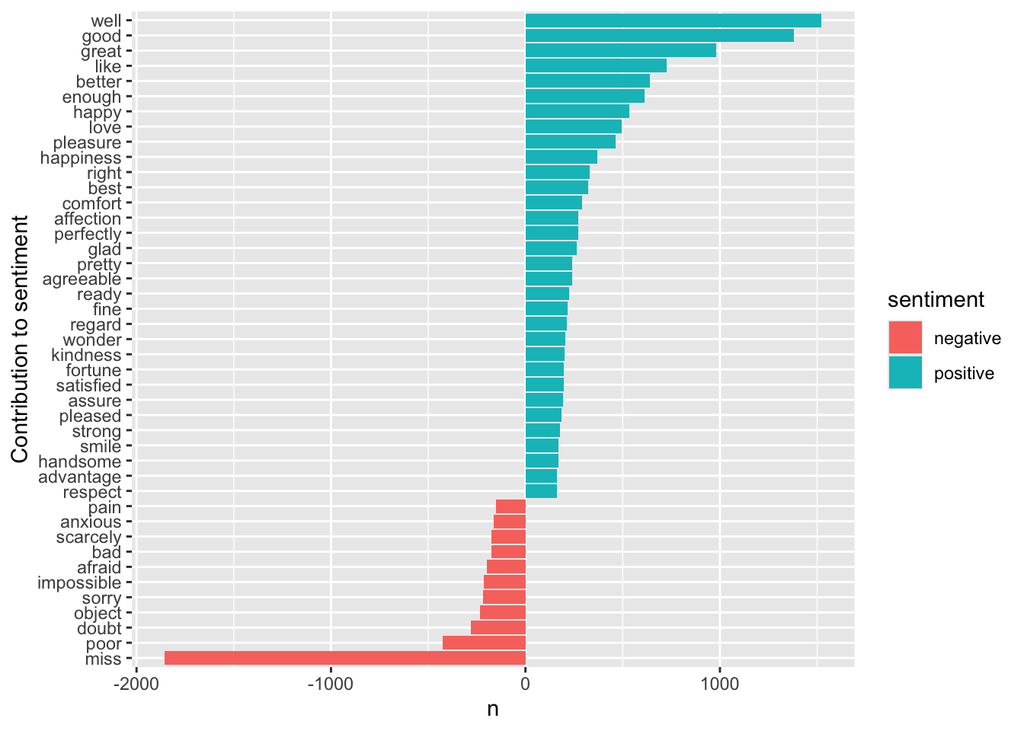

```r
sent_word_counts |>
  filter(n > 150) |> # take only if there are over 150 instances of it (in the n column)
  mutate(n = ifelse(sentiment == "negative", -n, n)) |> # add a column where if the word is negative make the count negative
  mutate(word = reorder(word, n)) |> # sort it so it goes from largest to smallest from most pos to most neg
  ggplot(aes(x = n, y = word, fill = sentiment)) +
  geom_col() +
  labs(y = "Contribution to sentiment")
```

#### Make a Wordcloud

Use the {wordcloud} package to make a word cloud:

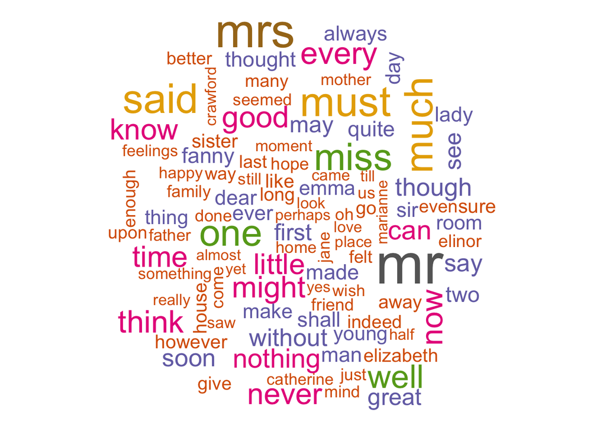

```r
words <- cleaned_books |>
  count(word) |> # count all the words
  arrange(desc(n)) |> # sort the words
  slice(1:100) # take the top 100

wordcloud(words = words$word, freq = words$n, colors = brewer.pal(8, "Dark2")) # words$n means how freq words are in the box determines size
```

**Today’s Totally Awesome R Package — {ggirl}** {ggirl} (gg in real life) Have you ever made a plot that you love so much and thought, “I want to send this to someone!” Well, now you can! Turn your ggplots into a postcard.